# Proyek Analisis Data : Bike Sharing Dataset

## Import Semua Packages/Library yang Digunakan

```python
%pip install pandas matplotlib seaborn scikit-learn statsmodels
```

```python
# Import libraries
import pandas as pd
import matplotlib.pyplot as plt
import seaborn as sns
from sklearn.preprocessing import StandardScaler
from sklearn.cluster import KMeans
import statsmodels.api as sm
```

## Data Wrangling

### Gathering Data

Kita akan membaca file hour.csv menggunakan pandas dan memeriksa beberapa baris pertama untuk memahami struktur dataset.

```python
# Gathering Data: Baca file CSV
df = pd.read_csv('hour.csv')

# Menampilkan 5 baris pertama untuk melihat struktur dataset
df.head()
```

|  | instant | dteday | season | yr | mnth | hr | holiday | weekday | workingday | weathersit | temp | atemp | hum | windspeed | casual | registered | cnt |
| --- | --- | --- | --- | --- | --- | --- | --- | --- | --- | --- | --- | --- | --- | --- | --- | --- | --- |
| 0 | 1 | 2011-01-01 | 1 | 0 | 1 | 0 | 0 | 6 | 0 | 1 | 0.24 | 0.2879 | 0.81 | 0.0 | 3 | 13 | 16 |
| 1 | 2 | 2011-01-01 | 1 | 0 | 1 | 1 | 0 | 6 | 0 | 1 | 0.22 | 0.2727 | 0.80 | 0.0 | 8 | 32 | 40 |
| 2 | 3 | 2011-01-01 | 1 | 0 | 1 | 2 | 0 | 6 | 0 | 1 | 0.22 | 0.2727 | 0.80 | 0.0 | 5 | 27 | 32 |
| 3 | 4 | 2011-01-01 | 1 | 0 | 1 | 3 | 0 | 6 | 0 | 1 | 0.24 | 0.2879 | 0.75 | 0.0 | 3 | 10 | 13 |
| 4 | 5 | 2011-01-01 | 1 | 0 | 1 | 4 | 0 | 6 | 0 | 1 | 0.24 | 0.2879 | 0.75 | 0.0 | 0 | 1 | 1 |

**Insight:**

- Kita mendapatkan gambaran awal tentang kolom apa saja yang ada di dataset, seperti dteday, hr, temp, hum, cnt yang nanti akan kita gunakan untuk analisis

### Assessing Data

Pada tahap ini, kita akan menilai data pada dataset untuk mencari potensi masalah, baik berupa data yang hilang, data anomali, maupun format yang tidak sesuai.

```python
# Menampilkan informasi tentang tipe data, jumlah kolom, dan apakah ada nilai yang hilang.
df.info()
```

```
<class 'pandas.core.frame.DataFrame'>
RangeIndex: 17379 entries, 0 to 17378
Data columns (total 17 columns):
 #   Column      Non-Null Count  Dtype
---  ------      --------------  -----
 0   instant     17379 non-null  int64
 1   dteday      17379 non-null  object
 2   season      17379 non-null  int64
 3   yr          17379 non-null  int64
 4   mnth        17379 non-null  int64
 5   hr          17379 non-null  int64
 6   holiday     17379 non-null  int64
 7   weekday     17379 non-null  int64
 8   workingday  17379 non-null  int64
 9   weathersit  17379 non-null  int64
 10  temp        17379 non-null  float64
 11  atemp       17379 non-null  float64
 12  hum         17379 non-null  float64
 13  windspeed   17379 non-null  float64
 14  casual      17379 non-null  int64
 15  registered  17379 non-null  int64
 16  cnt         17379 non-null  int64
dtypes: float64(4), int64(12), object(1)
memory usage: 2.3+ MB
```

```python
# Mengecek apakah ada missing values
df.isnull().sum()
```

```
instant       0
dteday        0
season        0
yr            0
mnth          0
hr            0
holiday       0
weekday       0
workingday    0
weathersit    0
temp          0
atemp         0
hum           0
windspeed     0
casual        0
registered    0
cnt           0
dtype: int64
```

```python
# Mengecek apakah ada data duplikat
df.duplicated().sum()
```

```
np.int64(0)
```

**Insight:**

- Ternyata tidak ada column yang datanya bernilai null
- Ternyata tidak ada column duplicate

### Cleaning Data

Meskipun tidak ada missing values di dataset, masih ada beberapa langkah pembersihan (cleaning) yang dapat dilakukan untuk meningkatkan kualitas data.

#### Mengubah type dteday menjadi Datetime

```python
# Mengubah kolom 'dteday' menjadi tipe datetime
df['dteday'] = pd.to_datetime(df['dteday'])
```

#### Menghapus column yang tidak berkaitan dengan analisis

Kolom yang tidak relevan (seperti instant, casual, dan registered, yang tidak kita gunakan dalam analisis) dihapus untuk menyederhanakan dataset.

```python
df = df.drop(columns=['instant', 'casual', 'registered'])
```

#### Mentransformasi data

Beberapa kolom dalam dataset menggunakan kode numerik untuk mewakili kategori (seperti season, weathersit, holiday, workingday, dll.). Kita dapat mengubah kolom-kolom ini menjadi teks yang lebih mudah dibaca

```python
# Mengkonversi isi kolom agar mudah dipahami
# konversi season menjadi: 1:Spring, 2:Summer, 3:Fall, 4:Winter
df['season'] = df.season.replace((1,2,3,4), ('Spring','Summer','Fall','Winter'))

# konversi mnth menjadi: 1:Jan, 2:Feb, 3:Mar, 4:Apr, 5:May, 6:Jun, 7:Jul, 8:Aug, 9:Sep, 10:Oct, 11:Nov, 12:Dec
df['mnth'] = df.mnth.replace((1,2,3,4,5,6,7,8,9,10,11,12),('Jan','Feb','Mar','Apr','May','Jun','Jul','Aug','Sep','Oct','Nov','Dec'))

# konversi weathersit menjadi: 1:Clear, 2:Misty, 3:Light_RainSnow 4:Heavy_RainSnow
df['weathersit'] = df.weathersit.replace((1,2,3,4), ('Clear','Misty','Light Rain/Snow','Heavy Rain/Snow'))

# konversi weekday menjadi: 0:Sun, 1:Mon, 2:Tue, 3:Wed, 4:Thu, 5:Fri, 6:Sat
df['weekday'] = df.weekday.replace((0,1,2,3,4,5,6), ('Sunday','Monday','Tuesday','Wednesday','Thursday','Friday','Saturday'))

# konversi yr menjadi: 0:2011, 1:2012
df['yr'] = df.yr.replace((0,1), ('2011','2012'))


# Cek hasil perubahan tipe data
df.head()
```

|  | dteday | season | yr | mnth | hr | holiday | weekday | workingday | weathersit | temp | atemp | hum | windspeed | cnt |
| --- | --- | --- | --- | --- | --- | --- | --- | --- | --- | --- | --- | --- | --- | --- |
| 0 | 2011-01-01 | Spring | 2011 | Jan | 0 | 0 | Saturday | 0 | Clear | 0.24 | 0.2879 | 0.81 | 0.0 | 16 |
| 1 | 2011-01-01 | Spring | 2011 | Jan | 1 | 0 | Saturday | 0 | Clear | 0.22 | 0.2727 | 0.80 | 0.0 | 40 |
| 2 | 2011-01-01 | Spring | 2011 | Jan | 2 | 0 | Saturday | 0 | Clear | 0.22 | 0.2727 | 0.80 | 0.0 | 32 |
| 3 | 2011-01-01 | Spring | 2011 | Jan | 3 | 0 | Saturday | 0 | Clear | 0.24 | 0.2879 | 0.75 | 0.0 | 13 |
| 4 | 2011-01-01 | Spring | 2011 | Jan | 4 | 0 | Saturday | 0 | Clear | 0.24 | 0.2879 | 0.75 | 0.0 | 1 |

#### Mengembalikan data yang dinormalisasi ke skala asli

Kolom temp, atemp, hum, dan windspeed adalah nilai yang dinormalisasi (dibagi dengan nilai maksimum tertentu). Agar lebih mudah dipahami dalam konteks aslinya, kita bisa mengembalikan nilai-nilai ini ke skala sebenarnya. Dengan mengembalikan nilai-nilai ini ke skala aslinya, analisis suhu, kelembapan, dan kecepatan angin akan lebih mudah dipahami dan sesuai konteks.

```python
# Mengembalikan nilai-nilai ke skala asli
df['temp'] = df['temp'] * 41  # Skala suhu asli
df['atemp'] = df['atemp'] * 50  # Skala temperatur terasa asli
df['hum'] = df['hum'] * 100  # Skala kelembapan asli
df['windspeed'] = df['windspeed'] * 67  # Skala kecepatan angin asli

# Cek beberapa data setelah dikembalikan ke skala asli
df[['temp', 'atemp', 'hum', 'windspeed']].head()
```

|  | temp | atemp | hum | windspeed |
| --- | --- | --- | --- | --- |
| 0 | 9.84 | 14.395 | 81.0 | 0.0 |
| 1 | 9.02 | 13.635 | 80.0 | 0.0 |
| 2 | 9.02 | 13.635 | 80.0 | 0.0 |
| 3 | 9.84 | 14.395 | 75.0 | 0.0 |
| 4 | 9.84 | 14.395 | 75.0 | 0.0 |

#### Menghilangkan outlier pada column cnt

```python
# Menentukan batas outlier menggunakan IQR (Interquartile Range)
Q1 = df['cnt'].quantile(0.25)
Q3 = df['cnt'].quantile(0.75)
IQR = Q3 - Q1

# Mendefinisikan batas bawah dan batas atas untuk outlier
lower_bound = Q1 - 1.5 * IQR
upper_bound = Q3 + 1.5 * IQR

# Menghapus data yang termasuk outlier berdasarkan batas IQR
df = df[(df['cnt'] >= lower_bound) & (df['cnt'] <= upper_bound)]

# Cek hasil setelah outlier dihapus
df.shape
```

```
(16874, 14)
```

Terlihat ada beberapa data yang dihapus

### Kesimpulan Setelah Data Wrangling:

- Dataset sudah bersih dan siap untuk dianalisis lebih lanjut. Kita telah memastikan tidak ada data yang hilang atau duplikat, dan kolom-kolom yang tidak diperlukan sudah dihapus.
- Dataset kini siap untuk proses Exploratory Data Analysis (EDA), termasuk visualisasi dan analisis lanjutan.

## Exploratory Data Analysis (EDA)

```python
# melihat rangkuman parameter statistik dari data frame
df.describe(include="all")
```

|  | dteday | season | yr | mnth | hr | holiday | weekday | workingday | weathersit | temp | atemp | hum | windspeed | cnt |
| --- | --- | --- | --- | --- | --- | --- | --- | --- | --- | --- | --- | --- | --- | --- |
| count | 16874 | 16874 | 16874 | 16874 | 16874.000000 | 16874.000000 | 16874 | 16874.000000 | 16874 | 16874.000000 | 16874.000000 | 16874.000000 | 16874.000000 | 16874.000000 |
| unique | NaN | 4 | 2 | 12 | NaN | NaN | 7 | NaN | 4 | NaN | NaN | NaN | NaN | NaN |
| top | NaN | Fall | 2011 | Dec | NaN | NaN | Sunday | NaN | Clear | NaN | NaN | NaN | NaN | NaN |
| freq | NaN | 4298 | 8644 | 1470 | NaN | NaN | 2474 | NaN | 11020 | NaN | NaN | NaN | NaN | NaN |
| mean | 2011-12-26 23:54:06.699063808 | NaN | NaN | NaN | 11.458101 | 0.029513 | NaN | 0.678618 | NaN | 20.198659 | 23.598507 | 63.041247 | 12.704465 | 172.710146 |
| min | 2011-01-01 00:00:00 | NaN | NaN | NaN | 0.000000 | 0.000000 | NaN | 0.000000 | NaN | 0.820000 | 0.000000 | 0.000000 | 0.000000 | 1.000000 |
| 25% | 2011-06-29 00:00:00 | NaN | NaN | NaN | 5.000000 | 0.000000 | NaN | 0.000000 | NaN | 13.940000 | 16.665000 | 48.000000 | 7.001500 | 38.000000 |
| 50% | 2011-12-23 00:00:00 | NaN | NaN | NaN | 11.000000 | 0.000000 | NaN | 1.000000 | NaN | 20.500000 | 24.240000 | 63.000000 | 11.999700 | 135.000000 |
| 75% | 2012-06-23 00:00:00 | NaN | NaN | NaN | 18.000000 | 0.000000 | NaN | 1.000000 | NaN | 26.240000 | 31.060000 | 79.000000 | 16.997900 | 265.750000 |
| max | 2012-12-31 00:00:00 | NaN | NaN | NaN | 23.000000 | 1.000000 | NaN | 1.000000 | NaN | 41.000000 | 50.000000 | 100.000000 | 56.996900 | 642.000000 |
| std | NaN | NaN | NaN | NaN | 6.962144 | 0.169244 | NaN | 0.467021 | NaN | 7.890669 | 8.593924 | 19.260013 | 8.204795 | 155.020918 |

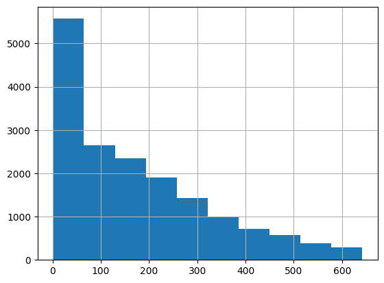

```python
df["cnt"].hist()
```

## Visualization & Explanatory Analysis

### Pertanyaan 1: Bagaimana pola penggunaan sepeda berbeda berdasarkan kondisi cuaca dalam tiga bulan terakhir di tahun 2012?

#### Langkah 1: Filter Data untuk Tiga Bulan Terakhir Tahun 2012

```python
df_filtered = df[(df['yr'] == '2012') & (df['mnth'].isin(['Oct','Nov','Dec']))]
```

#### Langkah 2: Kelompokkan Data Berdasarkan Kondisi Cuaca dan Hitung Rata-rata Pengguna Sepeda

**Penjelasan:** Data dikelompokkan berdasarkan kondisi cuaca (weathersit), lalu dihitung rata-rata jumlah pengguna sepeda (cnt) untuk setiap kategori cuaca.

```python
# Menghitung rata-rata pengguna sepeda berdasarkan kondisi cuaca
average_users_by_weather = df_filtered.groupby('weathersit',observed=False)['cnt'].mean().reset_index()
```

#### Langkah 3: Visualisasi Pola Penggunaan Sepeda Berdasarkan Kondisi Cuaca

**Penjelasan:** Visualisasi barplot digunakan untuk memudahkan interpretasi perbedaan rata-rata pengguna sepeda berdasarkan kondisi cuaca. Ini akan membantu menemukan pola penggunaan sepeda di berbagai kondisi cuaca.

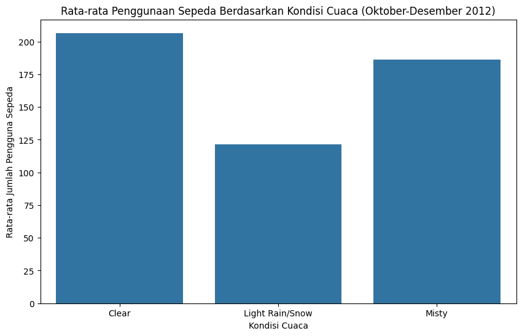

```python
# Visualisasi rata-rata penggunaan sepeda berdasarkan kondisi cuaca
plt.figure(figsize=(10, 6))
sns.barplot(x='weathersit', y='cnt', data=average_users_by_weather)
plt.title('Rata-rata Penggunaan Sepeda Berdasarkan Kondisi Cuaca (Oktober-Desember 2012)')
plt.xlabel('Kondisi Cuaca')
plt.ylabel('Rata-rata Jumlah Pengguna Sepeda')
plt.show()
```

Dari grafik tersebut, dapat disimpulkan bahwa cuaca memiliki pengaruh yang sangat besar terhadap minat masyarakat untuk menggunakan layanan berbagi sepeda. Cuaca cerah menjadi faktor pendorong, sementara cuaca buruk menjadi penghalang. Hasil ini sejalan dengan intuisi kita bahwa kondisi cuaca yang baik akan mendorong lebih banyak orang untuk beraktivitas di luar ruangan, termasuk bersepeda.

### Pertanyaan 2: Apakah ada hubungan antara suhu udara dan jumlah pengguna sepeda pada hari kerja di tahun 2011 dan 2012?

#### Langkah 1: Filter Data untuk Hari Kerja

Penjelasan: Data difilter untuk hanya mencakup hari kerja, karena kita ingin melihat hubungan antara suhu dan jumlah pengguna sepeda pada hari-hari kerja.

```python
df_workingday = df[df['workingday'] == 1]
```

#### Langkah 2: Visualisasi Hubungan antara Suhu dan Pengguna Sepeda

Penjelasan: Scatter plot digunakan untuk memvisualisasikan hubungan antara suhu udara (temp) dan jumlah pengguna sepeda (cnt). alpha=0.5 digunakan untuk membuat titik lebih transparan sehingga tumpang tindihnya tidak berlebihan.

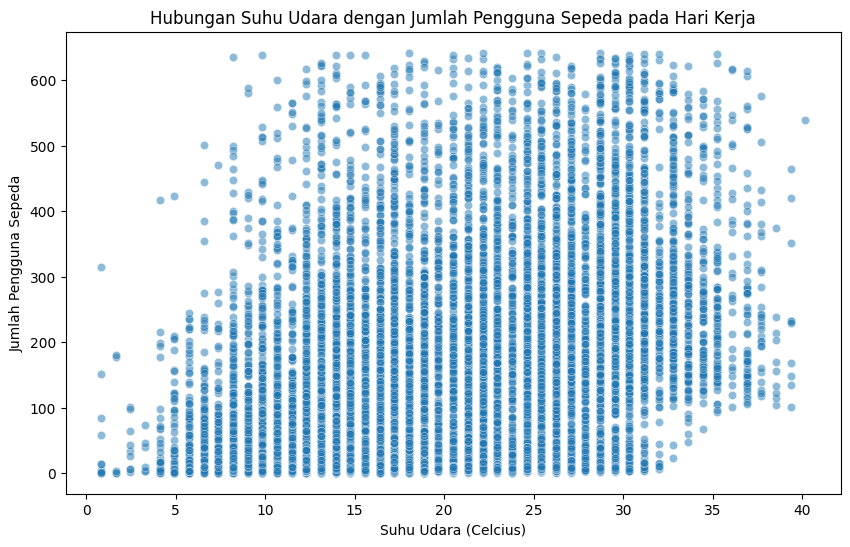

```python
# Visualisasi scatter plot hubungan suhu udara dengan jumlah pengguna sepeda
plt.figure(figsize=(10, 6))
sns.scatterplot(x='temp', y='cnt', data=df_workingday, alpha=0.5)
plt.title('Hubungan Suhu Udara dengan Jumlah Pengguna Sepeda pada Hari Kerja')
plt.xlabel('Suhu Udara (Celcius)')
plt.ylabel('Jumlah Pengguna Sepeda')
plt.show()
```

#### Langkah 3: Menghitung Korelasi Antara Suhu dan Jumlah Pengguna

Penjelasan: Korelasi Pearson digunakan untuk mengukur korelasi antara suhu udara (temp) dan jumlah pengguna sepeda (cnt). Nilai korelasi berkisar antara -1 hingga 1, dengan nilai mendekati 1 menunjukkan hubungan positif yang kuat.

```python
# Menghitung korelasi Pearson antara suhu dan jumlah pengguna sepeda
correlation = df_workingday[['temp', 'cnt']].corr(method='pearson')
correlation
```

|  | temp | cnt |
| --- | --- | --- |
| temp | 1.00000 | 0.34208 |
| cnt | 0.34208 | 1.00000 |

Nilai korelasi 0.34 menunjukkan adanya korelasi positif antara suhu (temp) dan jumlah pengguna sepeda (cnt). Namun, karena nilainya di bawah 0.5, hubungan ini tidak terlalu kuat, artinya suhu hanya salah satu faktor yang mempengaruhi jumlah pengguna sepeda. Meski korelasi tidak terlalu tinggi, hubungan positif ini menegaskan bahwa suhu yang lebih hangat berkontribusi pada peningkatan jumlah pengguna sepeda. Hal ini bisa berarti bahwa orang cenderung lebih suka menggunakan sepeda pada saat suhu lebih nyaman, tetapi mereka mungkin menghindari bersepeda saat cuaca terlalu panas atau terlalu dingin.

#### Langkah 4: Analisis Statistik Regresi Linier

Penjelasan: Di sini kita membangun model regresi linier untuk melihat apakah ada hubungan linier yang signifikan antara suhu udara dan jumlah pengguna sepeda. Hasil dari model memberikan informasi tentang kekuatan hubungan ini dan apakah secara statistik signifikan.

Ordinary Least Squares (OLS) adalah salah satu metode paling umum digunakan dalam regresi linear untuk memodelkan hubungan antara variabel independen (input) dan variabel dependen (output).

```python
# Menambahkan konstanta untuk regresi linier
X = sm.add_constant(df_workingday['temp'])
y = df_workingday['cnt']

# Membangun model regresi linier
model = sm.OLS(y, X).fit()
predictions = model.predict(X)

# Ringkasan hasil model
model.summary()
```

OLS Regression Results

| Dep. Variable: | cnt | R-squared: | 0.117 |
| --- | --- | --- | --- |
| Model: | OLS | Adj. R-squared: | 0.117 |
| Method: | Least Squares | F-statistic: | 1517. |
| Date: | Sat, 05 Oct 2024 | Prob (F-statistic): | 8.66e-312 |
| Time: | 17:51:34 | Log-Likelihood: | -73064. |
| No. Observations: | 11451 | AIC: | 1.461e+05 |
| Df Residuals: | 11449 | BIC: | 1.461e+05 |
| Df Model: | 1 |  |  |
| Covariance Type: | nonrobust |  |  |

|  | coef | std err | t | P>\|t\| | [0.025 | 0.975] |
| --- | --- | --- | --- | --- | --- | --- |
| const | 35.9636 | 3.753 | 9.581 | 0.000 | 28.606 | 43.321 |
| temp | 6.6755 | 0.171 | 38.953 | 0.000 | 6.340 | 7.011 |

| Omnibus: | 1189.471 | Durbin-Watson: | 0.479 |
| --- | --- | --- | --- |
| Prob(Omnibus): | 0.000 | Jarque-Bera (JB): | 1589.947 |
| Skew: | 0.881 | Prob(JB): | 0.00 |
| Kurtosis: | 3.478 | Cond. No. | 61.7 |

Notes:  
[1] Standard Errors assume that the covariance matrix of the errors is correctly specified.

Model ini menunjukkan bahwa suhu memiliki efek yang signifikan secara statistik pada jumlah pengguna sepeda, dengan hubungan positif. Namun, model hanya menjelaskan sebagian kecil dari variasi pengguna sepeda (11.7%), sehingga ada banyak faktor lain yang juga mempengaruhi penggunaan sepeda yang belum ditangkap oleh model ini.

## Analisis Lanjutan (Opsional)

### **Langkah 1: Persiapan Data**

```python
# Mengonversi kolom 'weathersit' menjadi dummy variables
weather_dummies = pd.get_dummies(df['weathersit'], prefix='weather')
df = pd.concat([df, weather_dummies], axis=1)
```

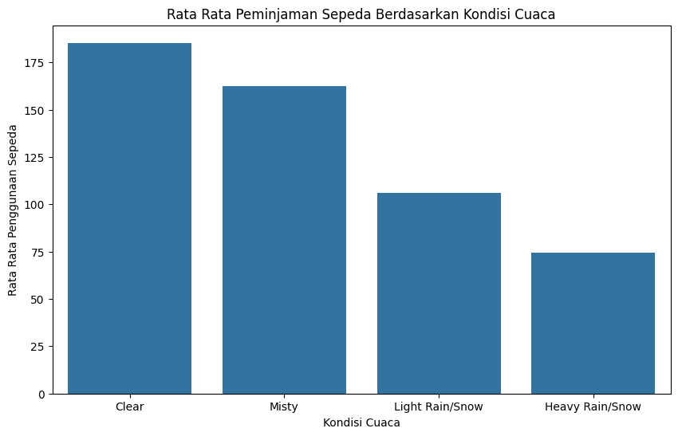

```python
data = df.groupby("weathersit",observed=False)["cnt"].mean().sort_values(ascending=False).reset_index()


plt.figure(figsize=(10, 6))
sns.barplot(x='weathersit', y='cnt', data=data)
plt.title('Rata Rata Peminjaman Sepeda Berdasarkan Kondisi Cuaca')
plt.xlabel('Kondisi Cuaca')
plt.ylabel('Rata Rata Penggunaan Sepeda')
plt.show()
```

## Conclusion

### Kesimpulan Akhir:

**Pertanyaan 1:** Pola penggunaan sepeda berdasarkan kondisi cuaca menunjukkan bahwa jumlah pengguna sepeda lebih tinggi saat cuaca cerah dan menurun dalam kondisi cuaca buruk (misalnya hujan/salju ringan atau berat). Ini memberi wawasan bahwa cuaca mempengaruhi keputusan orang untuk menggunakan layanan bike sharing.

**Pertanyaan 2:** Dari hasil korelasi dan regresi linier, kita dapat melihat apakah ada hubungan positif antara suhu udara dan jumlah pengguna sepeda pada hari kerja. Jika suhu meningkat, ada kemungkinan jumlah pengguna sepeda juga meningkat, yang menunjukkan penggunaan sepeda lebih nyaman di cuaca yang lebih hangat.